# AI-Enabled Research Bootcamp

From AI experimentation to research-ready workflows

Impact Analytics

World Bank Group

5 October 2026

## AI in practice, not in theory

This is a **hands-on bootcamp** about applying AI to real analytical work—with tools and workflows available in the World Bank environment.

### Bring your work

More than half of the sessions are hands-on. Work on your own project, or practice with the demo materials.

### Get dedicated support

Instructors sit at your tables and support you throughout. You can also post in the Teams channel.

### Build your pathway

Start with the foundations, then choose topics that fit your experience, interests, and work program.

### Use AI responsibly

Apply AI ethically and cost-effectively at every stage of the research cycle, from data collection to publication.

**Bring a real task—we’ll help you find where AI can make your workflows faster or better.**

## Who we are

Impact Analytics is part of the World Bank’s Development Impact Group. Its mission is to strengthen the **transparency, credibility, and reproducibility** of research.

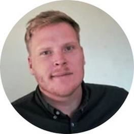

Kristoffer  
Bjärkefur

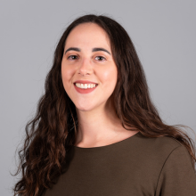

Maria  
Reyes Retana

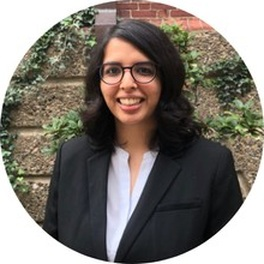

Ankriti  
Singh

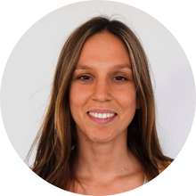

Marina  
Visintini

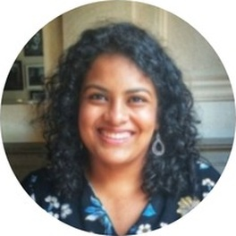

Roshni  
Khincha

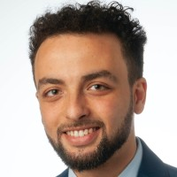

Jonas  
Weinert

This Bootcamp brings our practical approach to AI-enabled research workflows.

## Who you are: AI enthusiasts

[figure not shown]

You mostly use AI for writing and background research, through chat interfaces.

## …who don’t use AI for code much (yet)

[figure not shown]

**Coding agents can change this**—they work with your files and code, not just chat. **25%** have tried one; our goal: **everyone by the end of the Bootcamp**.

## What we’ll do: apply AI workflows across the research cycle

### Day 1 · Agentic AI at the WBG

Understand agents; onboard them to a project; use prompts, memory files, and skills; work efficiently and safely. **Leave with:** a project memory file and a reusable skill, installed and used.

### Day 2 · Data acquisition and analysis

Apply AI to surveys, transcription, data quality, code improvement, and reproducible tables and charts. **Leave with:** an AI-programmed survey, data-quality checks, improved code, and a table or chart.

### Day 3 · Reproducible research products

Use AI for literature, presentations, working papers, reproducibility packages, and an adoption plan. **Leave with:** a presentation or policy brief, a reproducibility package, and an adoption plan.

### Day 4 · Advanced workflows (optional)

Explore advanced tools: dashboards, multi-agent workflows, geospatial analysis, and more. **Leave with:** hands-on practice with advanced AI tools and workflows.

**Bring a real project.** Your outputs will reflect the sessions you attend.

## Today: understand agents, then put them to work

### 1 · Understand agents

- Introduction to AI agents
- Onboarding agents: memory files

### 2 · Explore AI at the WBG

- WBG GitHub and Open Source Catalog
- AI Tools Bazaar
- AI at the WBG: landscape and ambitions

### 3 · Put agents to work

- Using agents efficiently and cost-effectively
- Good prompts and reusable skills
- Hands-on Create a memory file and install a skill

### 4 · Use AI responsibly

- How We Use AI Matters: ethics, governance, and safe use

**By the end of today:** a memory file for your project and one skill installed and used.

## Before the next session

[figure not shown]

### [Take the baseline survey (if you haven’t yet)](https://survey.wb.surveycto.com/collect/ai_bootcamp_pre_survey?caseid=)

[figure not shown]

### [Join the Teams channel](https://teams.microsoft.com/l/team/19%3AWSQWckjEYr1wdopHGzlta4n0OUhBgYgBkSPKvZAU2X81%40thread.tacv2/conversations?groupId=c5942f33-8b4c-4896-b91c-c4627e950b69&tenantId=31a2fec0-266b-4c67-b56e-2796d8f59c36)

[figure not shown]

### [Open the course materials](https://dime-worldbank.github.io/ai-research-training/bootcamp/)

[figure not shown]

### [Make sure you have access to a coding agent](https://dime-worldbank.github.io/ai-research-training/bootcamp/sessions/day-0/setup-coding-agent/)

GitHub Copilot in VS Code or Claude Code both work; our examples use VS Code.